# Advanced iPython: Images, plots, and widgets

## Images

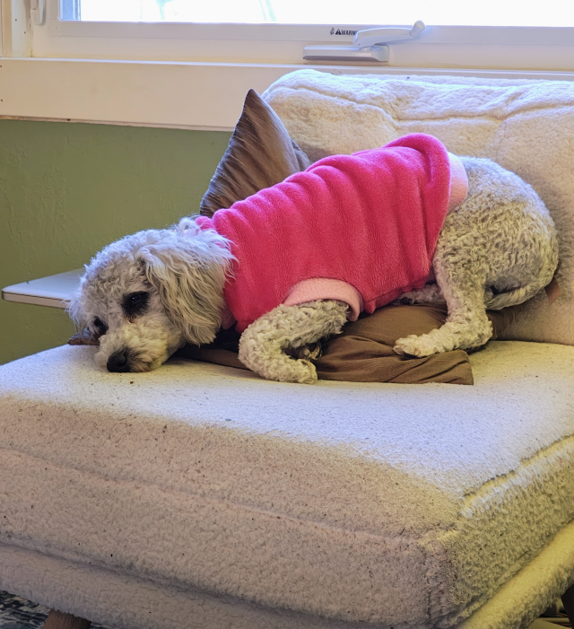

The easiest way to put an image into a notebook is to drag it into a markdown cell.

```python
%cd ~/jupyter_examples
```

```
/gpfs/home/emwin/jupyter_examples
```

We can also use `IPython.display` to display images. Let's display a stickleback.

```python
from IPython.display import Image
```

```python
sticklepic = Image('stickleback.jpg')
```

[figure not shown]

```python
display(sticklepic)
```

For manipulating images in Python, [PIL](https://pypi.org/project/pillow/) is popular.

```python
from PIL import Image
import numpy as np
img = np.asarray(Image.open('greta.png'))
```

```python
img.shape
```

```
(701, 640, 3)
```

And [matplotlib](https://matplotlib.org/) is used for visualization.

```python
import matplotlib.pyplot as plt
```

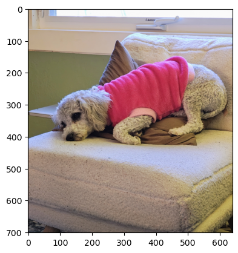

```python
plt.imshow(img)
```

Let's load in an example MRI image.

```python
import nibabel as nib
```

```python
brain_img = nib.load('sub-G16_T1w.nii')
```

```python
brain_data = brain_img.get_fdata()
```

This sequence of brain scan slices is 176 slices of 256 by 256 images.

```python
brain_data.shape
```

```
(176, 256, 256)
```

```python
import numpy as np
```

Here's a midbrain slice from the middle of the array.

```python
mid_slice = brain_data.take(indices=80, axis = 0)
```

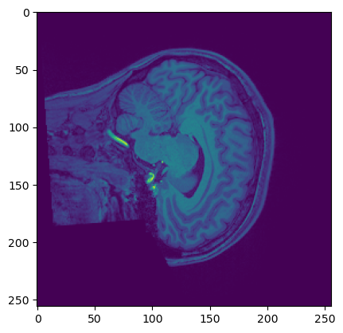

```python
plt.imshow(mid_slice)
```

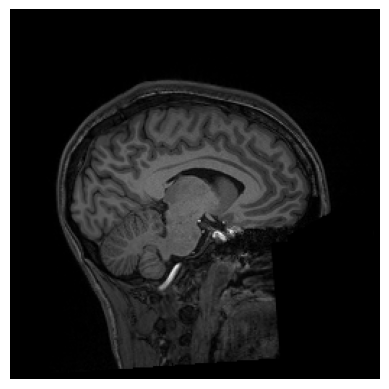

```python
plt.axis('off')
plt.imshow(np.rot90(mid_slice), cmap='gray');
```

## Plots

[Pandas](https://pandas.pydata.org/) is a handy data manipulation and visualization library that relies on DataFrames.

```python
import pandas as pd
```

```python
df = pd.read_csv('confounds.tsv', sep='\t')
```

```python
df
```

|  | global_signal | global_signal_derivative1 | csf | csf_derivative1 | white_matter | white_matter_derivative1 | csf_wm | std_dvars | dvars | framewise_displacement | ... | trans_y | trans_y_derivative1 | trans_z | trans_z_derivative1 | rot_x | rot_x_derivative1 | rot_y | rot_y_derivative1 | rot_z | rot_z_derivative1 |
| --- | --- | --- | --- | --- | --- | --- | --- | --- | --- | --- | --- | --- | --- | --- | --- | --- | --- | --- | --- | --- | --- |
| 0 | 6756.253228 | NaN | 7935.036545 | NaN | 6306.935358 | NaN | 6411.349510 | NaN | NaN | NaN | ... | -0.083524 | NaN | -0.158871 | NaN | 0.004992 | NaN | -0.002474 | NaN | 0.000454 | NaN |
| 1 | 6754.629673 | -1.623555 | 7894.489679 | -40.546867 | 6312.867043 | 5.931685 | 6416.429738 | 1.296169 | 46.046215 | 0.055823 | ... | -0.073538 | 0.009986 | -0.175832 | -0.016961 | 0.004757 | -0.000235 | -0.002412 | 0.000061 | 0.000518 | 0.000065 |
| 2 | 6746.590527 | -8.039146 | 7878.130544 | -16.359135 | 6304.041853 | -8.825190 | 6407.254461 | 1.286950 | 45.718697 | 0.098749 | ... | -0.088078 | -0.014540 | -0.143366 | 0.032466 | 0.005141 | 0.000384 | -0.002144 | 0.000268 | 0.000471 | -0.000047 |
| 3 | 6744.175585 | -2.414942 | 7857.751388 | -20.379156 | 6305.029893 | 0.988039 | 6407.896392 | 1.319555 | 46.876991 | 0.185253 | ... | -0.053224 | 0.034854 | -0.198539 | -0.055173 | 0.004098 | -0.001043 | -0.001933 | 0.000212 | 0.000886 | 0.000415 |
| 4 | 6746.437360 | 2.261776 | 7831.968803 | -25.782585 | 6309.318247 | 4.288354 | 6407.751868 | 1.275839 | 45.323986 | 0.120580 | ... | -0.095579 | -0.042355 | -0.149649 | 0.048890 | 0.004193 | 0.000095 | -0.001949 | -0.000017 | 0.000585 | -0.000301 |
| ... | ... | ... | ... | ... | ... | ... | ... | ... | ... | ... | ... | ... | ... | ... | ... | ... | ... | ... | ... | ... | ... |
| 183 | 6686.923536 | -39.534105 | 7771.207156 | -115.745747 | 6281.166375 | -27.946078 | 6382.155302 | 1.297638 | 46.098404 | 0.164141 | ... | 0.141959 | -0.036582 | 0.096598 | -0.029938 | -0.015813 | 0.001361 | 0.004989 | 0.000470 | -0.001601 | 0.000121 |
| 184 | 6651.701602 | -35.221934 | 7755.762249 | -15.444907 | 6232.834333 | -48.332042 | 6336.886394 | 1.685099 | 59.862885 | 1.082809 | ... | 0.054377 | -0.087582 | -0.365887 | -0.462485 | -0.007646 | 0.008167 | 0.006668 | 0.001679 | -0.001191 | 0.000410 |
| 185 | 6733.106227 | 81.404625 | 7757.295465 | 1.533215 | 6307.968988 | 75.134655 | 6403.098829 | 1.460791 | 51.894398 | 0.281366 | ... | 0.165888 | 0.111511 | -0.418908 | -0.053021 | -0.006529 | 0.001118 | 0.005871 | -0.000797 | -0.000774 | 0.000417 |
| 186 | 6719.283721 | -13.822506 | 7800.182728 | 42.887264 | 6297.643754 | -10.325234 | 6394.876807 | 1.257685 | 44.679085 | 0.225986 | ... | 0.105054 | -0.060834 | -0.347754 | 0.071154 | -0.005209 | 0.001319 | 0.006210 | 0.000339 | -0.000994 | -0.000220 |
| 187 | 6731.509593 | 12.225872 | 7903.294675 | 103.111946 | 6305.229667 | 7.585913 | 6405.514489 | 1.239190 | 44.022045 | 0.154345 | ... | 0.160395 | 0.055341 | -0.353609 | -0.005855 | -0.006169 | -0.000960 | 0.006573 | 0.000363 | -0.000480 | 0.000514 |

188 rows × 23 columns

```python
import seaborn as sns
```

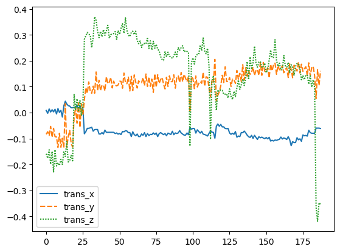

```python
sns.lineplot(data=df[['trans_x','trans_y','trans_z']]);
```

## Widgets

```python
import ipywidgets as widgets
```

```python
widgets.IntSlider()
```

```
IntSlider(value=0)
```

```python
widgets.ToggleButton(description='Click me')
```

```
ToggleButton(value=False, description='Click me')
```

```python
file = open("greta.png", 'rb')
image = file.read()
widgets.Image(value=image, format='png', width=300)
```

```
Image(value=b'\x89PNG\r\n\x1a\n\x00\x00\x00\rIHDR\x00\x00\x02\x80\x00\x00\x02\xbd\x08\x02\x00\x00\x00;KJ\x07\x…
```

We can save the widget and use it elsewhere

```python
slider = widgets.IntSlider()
```

```python
display(slider)
```

```
IntSlider(value=0)
```

```python
slider.value
```

```
31
```

### Interactions and observations

```python
from ipywidgets import interact
```

Here's a very simple function that returns "Hello" + the input variable.

```python
def f(x):
    return f'Hello {x}'
```

We can use interact to send our widget values to the function

```python
interact(f, x=slider);
```

```
interactive(children=(IntSlider(value=0, description='x'), Output()), _dom_classes=('widget-interact',))
```

We don't even have to create the widget first. We can send it a default value and ipywidgets will guess the best widget for it. Try a string, a float, a bool, etc.

```python
interact(f, x=100.0);
```

```
interactive(children=(FloatSlider(value=100.0, description='x', max=300.0, min=-100.0), Output()), _dom_classe…
```

##### To make two widgets interact with each other, use observe

```python
size_slider = widgets.IntSlider(max = 600, value = 300)
greta = widgets.Image(value=image, format='png', width=size_slider)

def update_greta(change):
    greta.width = size_slider.value

size_slider.observe(update_greta, 'value')
```

```python
display(size_slider)
display(greta)
```

```
IntSlider(value=300, max=600)
```

```
Image(value=b'\x89PNG\r\n\x1a\n\x00\x00\x00\rIHDR\x00\x00\x02\x80\x00\x00\x02\xbd\x08\x02\x00\x00\x00;KJ\x07\x…
```

The larger the number, the larger the picture of Greta.

### Interactive graph plotting

```python
selector = widgets.SelectMultiple(options=df.columns, value=[df.columns[0]])
rangeSlider = widgets.IntRangeSlider(max = len(df), value=(0, len(df)))

def myplot(columns, xrange):
    sns.lineplot(data=df[list(columns)].take(range(*xrange)))

interact(myplot, columns = selector, xrange=rangeSlider);
```

```
interactive(children=(SelectMultiple(description='columns', index=(0,), options=('global_signal', 'global_sign…
```

### Interactive brain viewer

```python
axis_radio = widgets.RadioButtons(options={'sagital':0, 'coronal':1, 'axial':2},
                                  description = 'Orientation',
                                  value=0)

slice_slider = widgets.IntSlider(max = brain_data.shape[0]-1,
                                 description = 'Slice',
                                 value = brain_data.shape[0]/2)

def update_slider(change):
    slice_slider.max = brain_data.shape[int(axis_radio.value)]-1
    slice_slider.value =  brain_data.shape[int(axis_radio.value)]/2

axis_radio.observe(update_slider, 'value')

def brain_plot(slice_number, axis):
    brain_slice = brain_data.take(indices=slice_number, axis = axis)
    plt.axis('off')
    plt.imshow(np.rot90(brain_slice), cmap='gray')


interact(brain_plot, slice_number = slice_slider, axis=axis_radio);
```

```
interactive(children=(IntSlider(value=88, description='Slice', max=175), RadioButtons(description='Orientation…
```